# Bənd-Test Korrelyasiyası

Tapşırıq Analizinin Əsas Metodları və Tətbiqi

Klassik Test Nəzəriyyəsi Kursu

2025-07-18

## 0.1 Dərsin Məqsədləri

✓ Bənd-test korrelyasiyası anlayışını və əhəmiyyətini anlamaq  
✓ Corrected item-total correlation hesablama və interpretasiya metodlarını öyrənmək  
✓ Düzəliş formullarının tətbiqi və nəzəri əsaslarını mənimsəmək  
✓ Bənd seçimi kriteriləri və test təkmilləşdirilməsi strategiyalarını qavramaq

## 0.2 Əvvəlki Dərslərə Baxış

**Dərs 1-12-də öyrəndiklərimiz:** - **Klassik Test Nəzəriyyəsi** və X = T + E modeli - **Etibarlılıq metodları** - test-retest, paralel formalar, split-half - **Cronbach Alpha** və daxili tutarlılıq prinsipi - **Tapşırıq analizinin** əsas mərhələləri

**İndi fokus:** Fərdi Tapşırıqlərin test keyfiyyətinə töhfəsini qiymətləndirmək - **Bənd-Test Korrelyasiyası**

# 1 **Bənd-Test Korrelyasiyasının Anlayışı**

## 1.1 **Məqsəd: Bənd və Ümumi Test Arasında Əlaqə**

**Allen və Yen (2002, səh. 123-127)** kitabında bənd-test korrelyasiyası belə təyin edilir:

> **Bənd-test korrelyasiyası** - fərdi Tapşırıqnin cavabları ilə ümumi test balları arasındakı korrelyasiyadır. Bu göstərici Tapşırıqnin test məqsədinə nə qədər xidmət etdiyini ölçür.

### 1.1.1 **Bənd-Test Korrelyasiyasının Xüsusiyyətləri**

```r
# Bənd-test korrelyasiyasının xarakteristikaları

item_total_characteristics <- data.frame(
  Xususiyyet = c("Diskriminasiya gücü", "Daxili tutarlılıq", "Test keyfiyyəti",
                 "Konstrukt validliyi", "Tapşırıq seçimi", "Etibarlılıq təsiri"),

  Izah = c("Yüksək/aşağı qabiliyyəti ayırma", "Tapşırıqlər arası əlaqə", "Ümumi test performansı",
           "Eyni konstruktu ölçmə", "Keyfiyyətli Tapşırıqlər", "Alpha əmsalına təsir"),

  Yüksək_Korrelyasiya = c("Yaxşı diskriminasiya", "Güclü daxili tutarlılıq", "Keyfiyyətli test",
                          "Konstrukt uyğunluğu", "Saxlanmalı Tapşırıq", "Etibarlılığı artırır"),

  Aşağı_Korrelyasiya = c("Zəif diskriminasiya", "Tutarsızlıq", "Keyfiyyətsiz test",
                         "Konstrukt uyğunsuzluğu", "Çıxarılmalı Tapşırıq", "Etibarlılığı azaldır"),

  Kritik_Səviyyə = c(0.3, 0.25, 0.35, 0.4, 0.3, 0.25)
)

kable(item_total_characteristics[,-5], caption = "Bənd-Test Korrelyasiyasının Xüsusiyyətləri")
```

Bənd-Test Korrelyasiyasının Xüsusiyyətləri

| Xususiyyet | Izah | Yüksək_Korrelyasiya | Aşağı_Korrelyasiya |
| --- | --- | --- | --- |
| Diskriminasiya gücü | Yüksək/aşağı qabiliyyəti ayırma | Yaxşı diskriminasiya | Zəif diskriminasiya |
| Daxili tutarlılıq | Tapşırıqlər arası əlaqə | Güclü daxili tutarlılıq | Tutarsızlıq |
| Test keyfiyyəti | Ümumi test performansı | Keyfiyyətli test | Keyfiyyətsiz test |
| Konstrukt validliyi | Eyni konstruktu ölçmə | Konstrukt uyğunluğu | Konstrukt uyğunsuzluğu |
| Tapşırıq seçimi | Keyfiyyətli Tapşırıqlər | Saxlanmalı Tapşırıq | Çıxarılmalı Tapşırıq |
| Etibarlılıq təsiri | Alpha əmsalına təsir | Etibarlılığı artırır | Etibarlılığı azaldır |

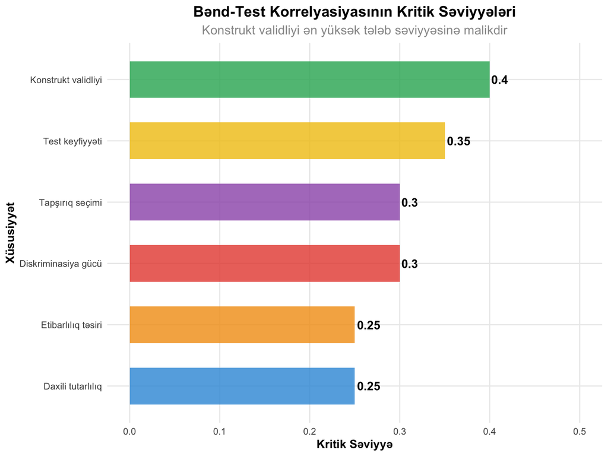

```r
# Kritik səviyyələrin vizuallaşdırılması
ggplot(item_total_characteristics, aes(x = reorder(Xususiyyet, Kritik_Səviyyə),
                                      y = Kritik_Səviyyə, fill = Xususiyyet)) +
  geom_col(alpha = 0.8, width = 0.6) +
  geom_text(aes(label = round(Kritik_Səviyyə, 2)), hjust = -0.1,
            fontface = "bold", size = 4) +
  coord_flip() +
  scale_fill_manual(values = colors_basic[1:nrow(item_total_characteristics)]) +
  labs(title = "Bənd-Test Korrelyasiyasının Kritik Səviyyələri",
       subtitle = "Konstrukt validliyi ən yüksək tələb səviyyəsinə malikdir",
       x = "Xüsusiyyət", y = "Kritik Səviyyə") +
  theme_clean() +
  theme(legend.position = "none") +
  ylim(0, 0.5)
```

## 1.2 **Corrected Item-Total Correlation**

**Düzəliş edilmiş bənd-test korrelyasiyası** daha dəqiq ölçü verir:

### 1.2.1 **Formulalar:**

**Sadə bənd-test korrelyasiyası:** **r<sub>it</sub> = Cor(X<sub>i</sub>, X<sub>total</sub>)**

**Düzəliş edilmiş bənd-test korrelyasiyası:** **r<sub>i(t-i)</sub> = Cor(X<sub>i</sub>, X<sub>total</sub> - X<sub>i</sub>)**

```r
# Düzəliş edilmiş bənd-test korrelyasiyası simulyasiyası

set.seed(123)
n_participants <- 300
n_items <- 20

# Simulyasiya edilmiş test məlumatları
# Müxtəlif diskriminasiya gücünə malik Tapşırıqlər
item_discriminations <- c(rep(0.8, 5), rep(0.6, 5), rep(0.4, 5), rep(0.2, 5))
item_difficulties <- runif(n_items, 0.3, 0.8)

# Tələbə qabiliyyətləri
abilities <- rnorm(n_participants, 0, 1)

# Tapşırıq cavabları yaradılması
item_responses <- matrix(0, nrow = n_participants, ncol = n_items)

for(i in 1:n_items) {
  # IRT 2PL modelindən istifadə
  discrimination <- item_discriminations[i]
  difficulty <- qnorm(item_difficulties[i])

  prob <- pnorm(discrimination * (abilities - difficulty))
  item_responses[, i] <- rbinom(n_participants, 1, prob)
}

# Ümumi test balları
total_scores <- rowSums(item_responses)

# Bənd-test korrelyasiyalarının hesablanması
item_total_results <- data.frame(
  Tapşırıq = 1:n_items,
  Çətinlik = round(colMeans(item_responses), 3),
  Diskriminasiya_Həqiqi = item_discriminations,
  Sadə_Korrelyasiya = numeric(n_items),
  Düzəliş_Korrelyasiya = numeric(n_items),
  Alfa_Çıxarıldıqda = numeric(n_items)
)

# Hər Tapşırıq üçün korrelyasiyalar
for(i in 1:n_items) {
  # Sadə bənd-test korrelyasiyası
  item_total_results$Sadə_Korrelyasiya[i] <- cor(item_responses[, i], total_scores)

  # Düzəliş edilmiş bənd-test korrelyasiyası
  corrected_total <- total_scores - item_responses[, i]
  item_total_results$Düzəliş_Korrelyasiya[i] <- cor(item_responses[, i], corrected_total)

  # Alpha Tapşırıq çıxarıldıqda
  remaining_items <- item_responses[, -i]
  item_total_results$Alfa_Çıxarıldıqda[i] <- psych::alpha(remaining_items)$total$raw_alpha
}

# Nəticələri yuvarlaqlama
item_total_results[, 4:6] <- round(item_total_results[, 4:6], 3)

# İlk 10 Tapşırıqnin nəticələri
cat("=== BƏND-TEST KORRELYASIYA ANALİZİ ===\n")
```

```
## === BƏND-TEST KORRELYASIYA ANALİZİ ===
```

```r
print(kable(head(item_total_results, 10), caption = "İlk 10 Tapşırıqnin Bənd-Test Korrelyasiyaları"))
```

```
##
##
## Table: İlk 10 Tapşırıqnin Bənd-Test Korrelyasiyaları
##
## | Tapşırıq| Çətinlik| Diskriminasiya_Həqiqi| Sadə_Korrelyasiya| Düzəliş_Korrelyasiya| Alfa_Çıxarıldıqda|
## |--------:|--------:|---------------------:|-----------------:|--------------------:|-----------------:|
## |        1|    0.523|                   0.8|             0.489|                0.380|             0.682|
## |        2|    0.360|                   0.8|             0.535|                0.436|             0.677|
## |        3|    0.540|                   0.8|             0.463|                0.351|             0.685|
## |        4|    0.373|                   0.8|             0.582|                0.489|             0.672|
## |        5|    0.327|                   0.8|             0.502|                0.402|             0.681|
## |        6|    0.567|                   0.6|             0.425|                0.311|             0.689|
## |        7|    0.490|                   0.6|             0.509|                0.402|             0.680|
## |        8|    0.397|                   0.6|             0.400|                0.285|             0.691|
## |        9|    0.477|                   0.6|             0.449|                0.336|             0.687|
## |       10|    0.510|                   0.6|             0.462|                0.350|             0.685|
```

```r
# Ümumi test statistikaları
overall_alpha <- psych::alpha(item_responses)$total$raw_alpha
mean_item_total <- mean(item_total_results$Düzəliş_Korrelyasiya)
sd_item_total <- sd(item_total_results$Düzəliş_Korrelyasiya)

cat("\n=== ÜMUMİ TEST STATİSTİKALARI ===\n")
```

```
##
## === ÜMUMİ TEST STATİSTİKALARI ===
```

```r
cat("Cronbach Alpha:", round(overall_alpha, 3), "\n")
```

```
## Cronbach Alpha: 0.704
```

```r
cat("Orta bənd-test korrelyasiyası:", round(mean_item_total, 3), "\n")
```

```
## Orta bənd-test korrelyasiyası: 0.274
```

```r
cat("Bənd-test korrelyasiyasının SD:", round(sd_item_total, 3), "\n")
```

```
## Bənd-test korrelyasiyasının SD: 0.129
```

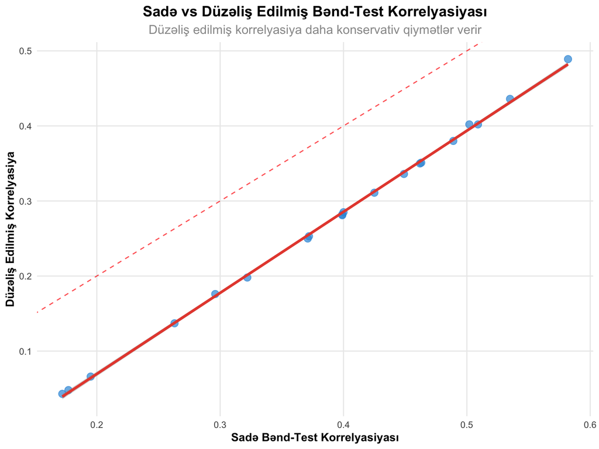

```r
# Korrelyasiyalar arası əlaqə
ggplot(item_total_results, aes(x = Sadə_Korrelyasiya, y = Düzəliş_Korrelyasiya)) +
  geom_point(alpha = 0.7, color = colors_basic[1], size = 3) +
  geom_smooth(method = "lm", color = colors_basic[2], size = 1.2, se = TRUE) +
  geom_abline(intercept = 0, slope = 1, linetype = "dashed", color = "red", alpha = 0.7) +
  labs(title = "Sadə vs Düzəliş Edilmiş Bənd-Test Korrelyasiyası",
       subtitle = "Düzəliş edilmiş korrelyasiya daha konservativ qiymətlər verir",
       x = "Sadə Bənd-Test Korrelyasiyası", y = "Düzəliş Edilmiş Korrelyasiya") +
  theme_clean()
```

# 2 **Düzəliş Formulları**

## 2.1 **Nəzəri Əsaslar**

**Allen və Yen (2002, səh. 128-132)** düzəliş formullarını ətraflı izah edir:

### 2.1.1 **Düzəliş Formullarının Növləri**

```r
# Düzəliş formullarının müqayisəsi

correction_formulas <- data.frame(
  Formula_Növü = c("Sadə Korrelyasiya", "Düzəliş Edilmiş", "Spearman-Brown",
                   "Attenuation Düzəlişi", "Disattenuated", "Part-Whole"),

  Riyazi_Ifadə = c("r(i,t)", "r(i,t-i)", "r' = 2r/(1+r)",
                   "r' = r/√(r₁₁×r₂₂)", "r(i,t)/√r(ii)", "r(i,t-i)/√(1-r²(i,t))"),

  Məqsəd = c("Əsas əlaqə", "Tapşırıq təsiri çıxarma", "Uzunluq düzəlişi",
             "Etibarlılıq düzəlişi", "Tapşırıq etibarlılığı", "Hissə-bütün əlaqəsi"),

  Tətbiq_Sahəsi = c("Başlanğıc analiz", "Tapşırıq seçimi", "Test uzunluğu",
                    "Validlik analizi", "Tapşırıq keyfiyyəti", "Nəzəri araşdırma"),

  Çətinlik_Səviyyəsi = c("Asan", "Orta", "Orta", "Çətin", "Çətin", "Çox çətin"),

  Praktik_Faydası = c(7, 9, 8, 6, 5, 4)
)

kable(correction_formulas[,-6], caption = "Düzəliş Formullarının Növləri və Xüsusiyyətləri")
```

Düzəliş Formullarının Növləri və Xüsusiyyətləri

| Formula_Növü | Riyazi_Ifadə | Məqsəd | Tətbiq_Sahəsi | Çətinlik_Səviyyəsi |
| --- | --- | --- | --- | --- |
| Sadə Korrelyasiya | r(i,t) | Əsas əlaqə | Başlanğıc analiz | Asan |
| Düzəliş Edilmiş | r(i,t-i) | Tapşırıq təsiri çıxarma | Tapşırıq seçimi | Orta |
| Spearman-Brown | r’ = 2r/(1+r) | Uzunluq düzəlişi | Test uzunluğu | Orta |
| Attenuation Düzəlişi | r’ = r/√(r₁₁×r₂₂) | Etibarlılıq düzəlişi | Validlik analizi | Çətin |
| Disattenuated | r(i,t)/√r(ii) | Tapşırıq etibarlılığı | Tapşırıq keyfiyyəti | Çətin |
| Part-Whole | r(i,t-i)/√(1-r²(i,t)) | Hissə-bütün əlaqəsi | Nəzəri araşdırma | Çox çətin |

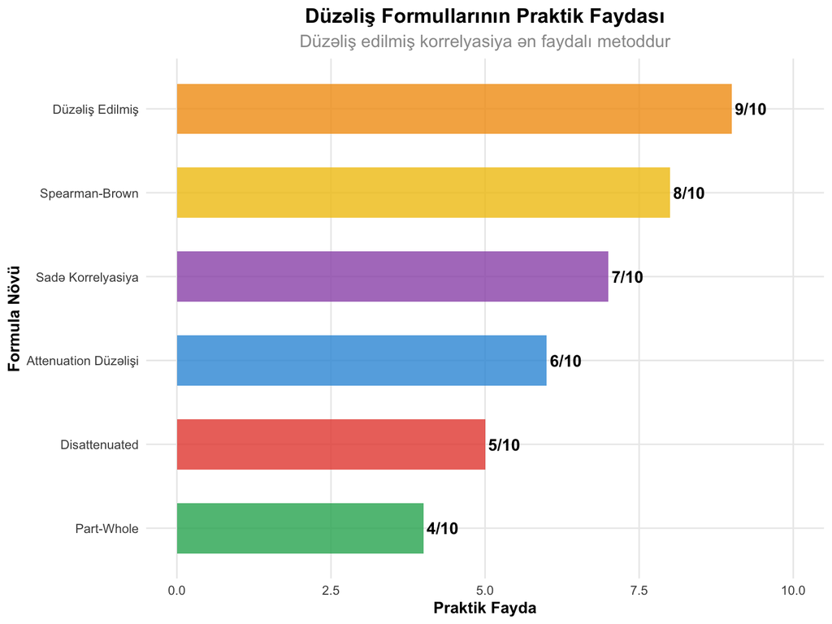

```r
# Praktik faydanın vizuallaşdırılması
ggplot(correction_formulas, aes(x = reorder(Formula_Növü, Praktik_Faydası),
                               y = Praktik_Faydası, fill = Formula_Növü)) +
  geom_col(alpha = 0.8, width = 0.6) +
  geom_text(aes(label = paste0(Praktik_Faydası, "/10")), hjust = -0.1,
            fontface = "bold", size = 4) +
  coord_flip() +
  scale_fill_manual(values = colors_basic[1:nrow(correction_formulas)]) +
  labs(title = "Düzəliş Formullarının Praktik Faydası",
       subtitle = "Düzəliş edilmiş korrelyasiya ən faydalı metoddur",
       x = "Formula Növü", y = "Praktik Fayda") +
  theme_clean() +
  theme(legend.position = "none") +
  ylim(0, 10)
```

## 2.2 **Düzəliş Formullarının Tətbiqi**

```r
# Düzəliş formullarının praktik tətbiqi

# Nümunə məlumat
set.seed(456)
n_subjects <- 150
n_items <- 15

# Test məlumatları
test_data <- matrix(rbinom(n_subjects * n_items, 1, 0.6),
                   nrow = n_subjects, ncol = n_items)
colnames(test_data) <- paste0("Item_", 1:n_items)

# Ümumi bal
total_score <- rowSums(test_data)

# Müxtəlif düzəliş metodlarının tətbiqi
correction_results <- data.frame(
  Tapşırıq = 1:n_items,
  Çətinlik = round(colMeans(test_data), 3),
  Sadə_r = numeric(n_items),
  Düzəliş_r = numeric(n_items),
  Spearman_Brown = numeric(n_items),
  Attenuation_r = numeric(n_items)
)

# Test etibarlılığı
test_alpha <- psych::alpha(test_data)$total$raw_alpha
```

[output not shown]

```r
for(i in 1:n_items) {
  # Sadə korrelyasiya
  simple_r <- cor(test_data[, i], total_score)
  correction_results$Sadə_r[i] <- simple_r

  # Düzəliş edilmiş korrelyasiya
  corrected_total <- total_score - test_data[, i]
  corrected_r <- cor(test_data[, i], corrected_total)
  correction_results$Düzəliş_r[i] <- corrected_r

  # Spearman-Brown düzəlişi
  sb_r <- (2 * simple_r) / (1 + simple_r)
  correction_results$Spearman_Brown[i] <- sb_r

  # Attenuation düzəlişi
  item_reliability <- var(test_data[, i])  # Binary üçün
  if(item_reliability > 0 && test_alpha > 0) {
    attenuation_r <- simple_r / sqrt(item_reliability * test_alpha)
    # Əgər nəticə məntiqi deyilsə, sadə korrelyasiya istifadə et
    if(is.finite(attenuation_r) && abs(attenuation_r) <= 1.5) {
      correction_results$Attenuation_r[i] <- attenuation_r
    } else {
      correction_results$Attenuation_r[i] <- simple_r
    }
  } else {
    correction_results$Attenuation_r[i] <- simple_r
  }
}

# Nəticələri yuvarlaqlama
correction_results[, 3:6] <- round(correction_results[, 3:6], 3)

print(kable(head(correction_results, 8), caption = "Düzəliş Formullarının Müqayisəsi"))
```

```
##
##
## Table: Düzəliş Formullarının Müqayisəsi
##
## |       | Tapşırıq| Çətinlik| Sadə_r| Düzəliş_r| Spearman_Brown| Attenuation_r|
## |:------|--------:|--------:|------:|---------:|--------------:|-------------:|
## |Item_1 |        1|    0.547|  0.212|    -0.070|          0.350|         0.212|
## |Item_2 |        2|    0.613|  0.353|     0.083|          0.522|         0.353|
## |Item_3 |        3|    0.600|  0.233|    -0.044|          0.378|         0.233|
## |Item_4 |        4|    0.540|  0.271|    -0.010|          0.427|         0.271|
## |Item_5 |        5|    0.513|  0.160|    -0.122|          0.276|         0.160|
## |Item_6 |        6|    0.593|  0.277|     0.000|          0.434|         0.277|
## |Item_7 |        7|    0.580|  0.266|    -0.013|          0.420|         0.266|
## |Item_8 |        8|    0.540|  0.128|    -0.153|          0.227|         0.128|
```

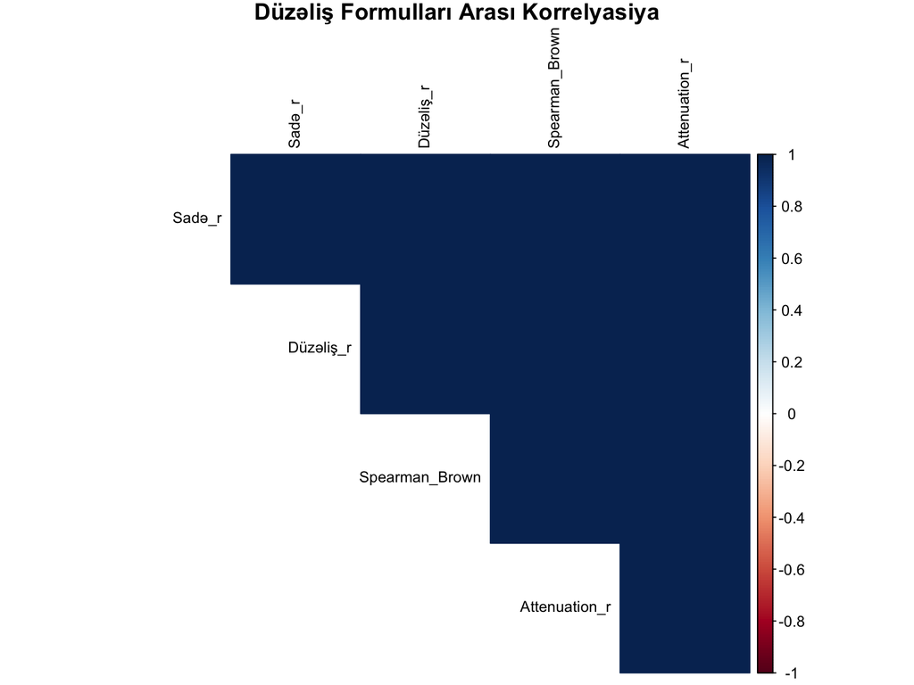

```r
# Formulalar arası korrelyasiya
# Əvvəlcə məlumatları yoxlayaq
cor_data <- correction_results[, 3:6]
complete_rows <- complete.cases(cor_data)

if(sum(complete_rows) > 5) {  # Ən azı 5 tam sətir olsun
  cor_matrix <- cor(cor_data[complete_rows, ], use = "complete.obs")

  # NA dəyərləri yoxla və əvəz et
  if(any(is.na(cor_matrix)) || any(is.infinite(cor_matrix))) {
    cor_matrix[is.na(cor_matrix) | is.infinite(cor_matrix)] <- 0
  }

  # Corrplot çəkmək
  corrplot(cor_matrix, method = "color", type = "upper",
           order = "original", tl.cex = 0.8, tl.col = "black",
           title = "Düzəliş Formulları Arası Korrelyasiya",
           mar = c(0,0,1,0))
} else {
  # Əgər kifayət qədər məlumat yoxdursa, sadə cədvəl göstər
  cat("Korrelyasiya matrisi üçün kifayət qədər tam məlumat yoxdur.\n")
  print(kable(cor_data, caption = "Düzəliş Formulları Məlumatları"))
}
```

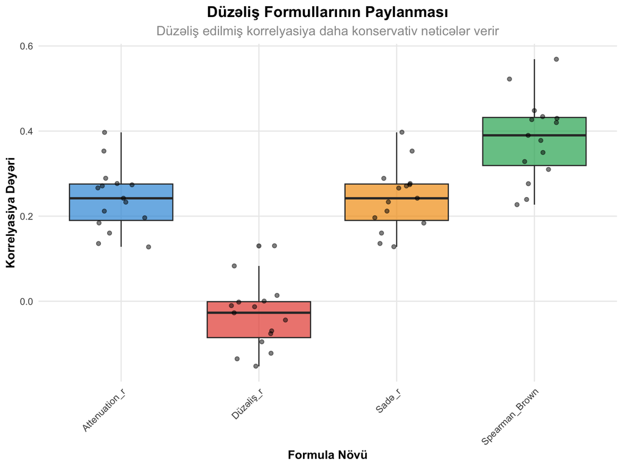

```r
# Formulaların paylanması
correction_long <- correction_results[, c("Tapşırıq", "Sadə_r", "Düzəliş_r", "Spearman_Brown", "Attenuation_r")]
correction_long <- tidyr::pivot_longer(correction_long, cols = c("Sadə_r", "Düzəliş_r", "Spearman_Brown", "Attenuation_r"),
                                      names_to = "Formula", values_to = "Korrelyasiya")

# NA dəyərləri çıxar
correction_long <- correction_long[!is.na(correction_long$Korrelyasiya), ]

ggplot(correction_long, aes(x = Formula, y = Korrelyasiya, fill = Formula)) +
  geom_boxplot(alpha = 0.7) +
  geom_jitter(width = 0.2, alpha = 0.5) +
  scale_fill_manual(values = colors_basic[1:4]) +
  labs(title = "Düzəliş Formullarının Paylanması",
       subtitle = "Düzəliş edilmiş korrelyasiya daha konservativ nəticələr verir",
       x = "Formula Növü", y = "Korrelyasiya Dəyəri") +
  theme_clean() +
  theme(legend.position = "none",
        axis.text.x = element_text(angle = 45, hjust = 1))
```

# 3 **Bənd Seçimi Kriteriləri**

## 3.1 **Keyfiyyətli Tapşırıqlərin Xüsusiyyətləri**

**Allen və Yen (2002, səh. 133-138)** Tapşırıq seçimi kriteriyalarını belə qruplaşdırır:

### 3.1.1 **Əsas Kriteriyalar**

```r
# Bənd seçimi kriteriləri

item_selection_criteria <- data.frame(
  Kriteriya = c("Bənd-test korrelyasiyası", "Çətinlik indeksi", "Diskriminasiya gücü",
                "Güzəranə effekti", "Seçenek analizi", "Qrup fərqləri"),

  Optimal_Aralıq = c("r > 0.30", "0.30 - 0.80", "d > 0.30",
                     "< 0.05", "Plausible", "DIF < 0.05"),

  Ölçmə_Metodu = c("Korrelyasiya", "p-dəyəri", "Qrup müqayisəsi",
                   "Təsadüfi cavab", "Distraktor analizi", "Mantel-Haenszel"),

  Qəbul_Hədd = c("Minimum 0.25", "Test məqsədinə uyğun", "Qrup ayırıcılığı",
                 "Statistik cəhətdən təsadüfi", "Cəlbedici yanlış", "Qrup ədalətsizliyi yox"),

  Prioritet = c(10, 9, 8, 6, 7, 8)
)

kable(item_selection_criteria[,-5], caption = "Bənd Seçimi Kriteriləri")
```

Bənd Seçimi Kriteriləri

| Kriteriya | Optimal_Aralıq | Ölçmə_Metodu | Qəbul_Hədd |
| --- | --- | --- | --- |
| Bənd-test korrelyasiyası | r > 0.30 | Korrelyasiya | Minimum 0.25 |
| Çətinlik indeksi | 0.30 - 0.80 | p-dəyəri | Test məqsədinə uyğun |
| Diskriminasiya gücü | d > 0.30 | Qrup müqayisəsi | Qrup ayırıcılığı |
| Güzəranə effekti | < 0.05 | Təsadüfi cavab | Statistik cəhətdən təsadüfi |
| Seçenek analizi | Plausible | Distraktor analizi | Cəlbedici yanlış |
| Qrup fərqləri | DIF < 0.05 | Mantel-Haenszel | Qrup ədalətsizliyi yox |

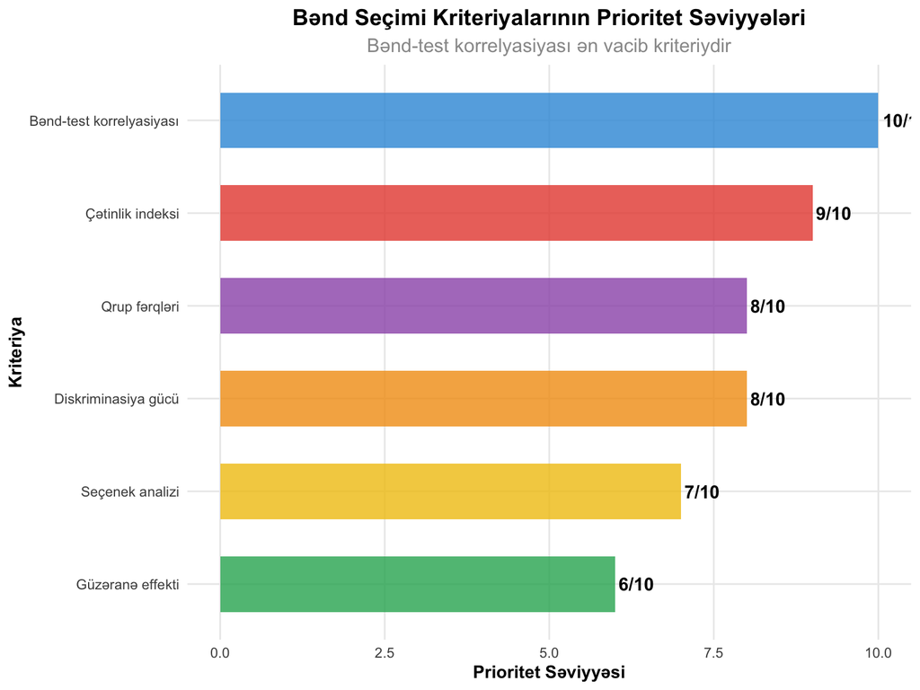

```r
# Prioritet səviyyələrinin vizuallaşdırılması
ggplot(item_selection_criteria, aes(x = reorder(Kriteriya, Prioritet),
                                   y = Prioritet, fill = Kriteriya)) +
  geom_col(alpha = 0.8, width = 0.6) +
  geom_text(aes(label = paste0(Prioritet, "/10")), hjust = -0.1,
            fontface = "bold", size = 4) +
  coord_flip() +
  scale_fill_manual(values = colors_basic[1:nrow(item_selection_criteria)]) +
  labs(title = "Bənd Seçimi Kriteriyalarının Prioritet Səviyyələri",
       subtitle = "Bənd-test korrelyasiyası ən vacib kriteriydir",
       x = "Kriteriya", y = "Prioritet Səviyyəsi") +
  theme_clean() +
  theme(legend.position = "none") +
  ylim(0, 10)
```

## 3.2 **Praktik Bənd Seçimi Strategiyaları**

```r
# Praktik bənd seçimi simulyasiyası

# Orijinal test məlumatları (əvvəlki nümunədən)
original_alpha <- psych::alpha(test_data)$total$raw_alpha
```

[output not shown]

```r
# Hər Tapşırıq üçün keyfiyyət göstəriciləri
item_quality_analysis <- data.frame(
  Tapşırıq = 1:n_items,
  Çətinlik = round(colMeans(test_data), 3),
  Bənd_Test_r = numeric(n_items),
  Diskriminasiya = numeric(n_items),
  Alfa_Çıxarıldıqda = numeric(n_items),
  Keyfiyyət_Qiymət = numeric(n_items),
  Tövsiyə = character(n_items)
)

# Yüksək və aşağı qabiliyyətli qruplar (27% metodu)
high_ability <- total_score >= quantile(total_score, 0.73)
low_ability <- total_score <= quantile(total_score, 0.27)

for(i in 1:n_items) {
  # Bənd-test korrelyasiyası
  corrected_total <- total_score - test_data[, i]
  item_total_r <- cor(test_data[, i], corrected_total)
  item_quality_analysis$Bənd_Test_r[i] <- item_total_r

  # Diskriminasiya gücü
  high_correct <- mean(test_data[high_ability, i])
  low_correct <- mean(test_data[low_ability, i])
  discrimination <- high_correct - low_correct
  item_quality_analysis$Diskriminasiya[i] <- discrimination

  # Alpha Tapşırıq çıxarıldıqda
  alpha_without <- psych::alpha(test_data[, -i])$total$raw_alpha
  item_quality_analysis$Alfa_Çıxarıldıqda[i] <- alpha_without

  # Keyfiyyət qiyməti (çoxlu kriteriya)
  quality_score <- 0
  if(item_total_r >= 0.30) quality_score <- quality_score + 3
  else if(item_total_r >= 0.20) quality_score <- quality_score + 2
  else if(item_total_r >= 0.10) quality_score <- quality_score + 1

  if(discrimination >= 0.30) quality_score <- quality_score + 3
  else if(discrimination >= 0.20) quality_score <- quality_score + 2
  else if(discrimination >= 0.10) quality_score <- quality_score + 1

  difficulty <- item_quality_analysis$Çətinlik[i]
  if(difficulty >= 0.30 & difficulty <= 0.80) quality_score <- quality_score + 2
  else if(difficulty >= 0.20 & difficulty <= 0.90) quality_score <- quality_score + 1

  item_quality_analysis$Keyfiyyət_Qiymət[i] <- quality_score

  # Tövsiyə
  if(quality_score >= 6) {
    item_quality_analysis$Tövsiyə[i] <- "Əla - Saxla"
  } else if(quality_score >= 4) {
    item_quality_analysis$Tövsiyə[i] <- "Yaxşı - Saxla"
  } else if(quality_score >= 2) {
    item_quality_analysis$Tövsiyə[i] <- "Orta - Bax"
  } else {
    item_quality_analysis$Tövsiyə[i] <- "Zəif - Çıxar"
  }
}
```

[output not shown]

[output not shown]

[output not shown]

[output not shown]

[output not shown]

[output not shown]

[output not shown]

[output not shown]

[output not shown]

[output not shown]

[output not shown]

[output not shown]

[output not shown]

[output not shown]

[output not shown]

```r
# Nəticələri yuvarlaqlama
item_quality_analysis[, 2:6] <- round(item_quality_analysis[, 2:6], 3)

print(kable(item_quality_analysis, caption = "Bənd Keyfiyyət Analizi və Tövsiyələr"))
```

```
##
##
## Table: Bənd Keyfiyyət Analizi və Tövsiyələr
##
## |        | Tapşırıq| Çətinlik| Bənd_Test_r| Diskriminasiya| Alfa_Çıxarıldıqda| Keyfiyyət_Qiymət|Tövsiyə       |
## |:-------|--------:|--------:|-----------:|--------------:|-----------------:|----------------:|:-------------|
## |Item_1  |        1|    0.547|      -0.070|          0.161|            -0.121|                3|Orta - Bax    |
## |Item_2  |        2|    0.613|       0.083|          0.420|            -0.231|                5|Yaxşı - Saxla |
## |Item_3  |        3|    0.600|      -0.044|          0.241|            -0.139|                4|Yaxşı - Saxla |
## |Item_4  |        4|    0.540|      -0.010|          0.296|            -0.163|                4|Yaxşı - Saxla |
## |Item_5  |        5|    0.513|      -0.122|          0.143|            -0.085|                3|Orta - Bax    |
## |Item_6  |        6|    0.593|       0.000|          0.276|            -0.171|                4|Yaxşı - Saxla |
## |Item_7  |        7|    0.580|      -0.013|          0.239|            -0.161|                4|Yaxşı - Saxla |
## |Item_8  |        8|    0.540|      -0.153|          0.144|            -0.064|                3|Orta - Bax    |
## |Item_9  |        9|    0.633|      -0.076|          0.100|            -0.117|                2|Orta - Bax    |
## |Item_10 |       10|    0.587|      -0.095|          0.167|            -0.104|                3|Orta - Bax    |
## |Item_11 |       11|    0.640|      -0.135|          0.137|            -0.079|                3|Orta - Bax    |
## |Item_12 |       12|    0.653|      -0.027|          0.226|            -0.151|                4|Yaxşı - Saxla |
## |Item_13 |       13|    0.607|      -0.002|          0.311|            -0.169|                5|Yaxşı - Saxla |
## |Item_14 |       14|    0.607|       0.014|          0.326|            -0.181|                5|Yaxşı - Saxla |
## |Item_15 |       15|    0.587|       0.130|          0.415|            -0.267|                6|Əla - Saxla   |
```

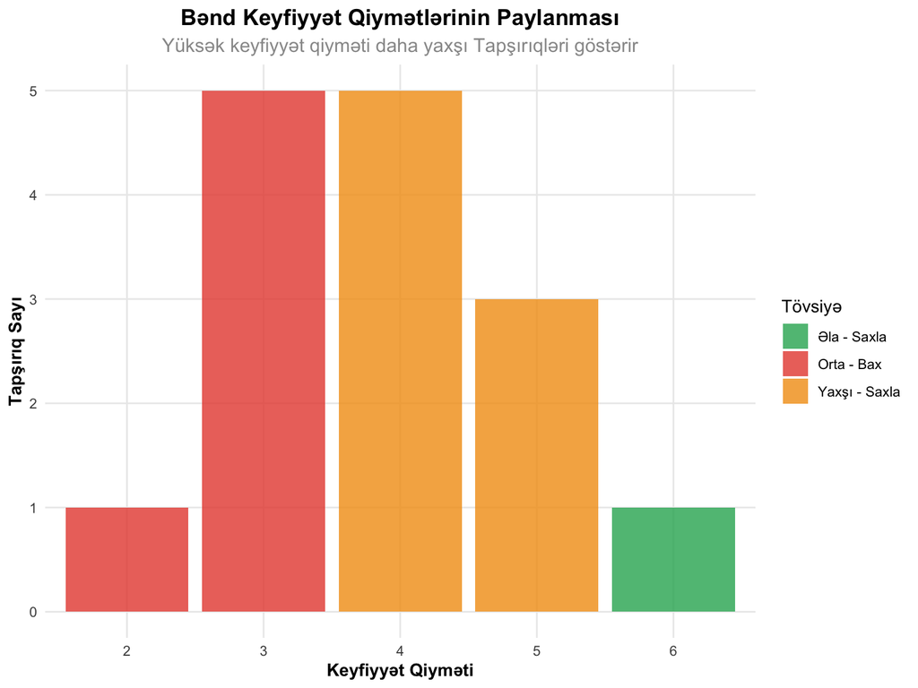

```r
# Keyfiyyət qiymətlərinin paylanması
ggplot(item_quality_analysis, aes(x = factor(Keyfiyyət_Qiymət), fill = Tövsiyə)) +
  geom_bar(alpha = 0.8) +
  scale_fill_manual(values = c("Əla - Saxla" = colors_basic[4],
                               "Yaxşı - Saxla" = colors_basic[3],
                               "Orta - Bax" = colors_basic[2],
                               "Zəif - Çıxar" = colors_basic[1])) +
  labs(title = "Bənd Keyfiyyət Qiymətlərinin Paylanması",
       subtitle = "Yüksək keyfiyyət qiyməti daha yaxşı Tapşırıqləri göstərir",
       x = "Keyfiyyət Qiyməti", y = "Tapşırıq Sayı", fill = "Tövsiyə") +
  theme_clean()
```

```r
# Tapşırıq seçimindən sonrakı test keyfiyyəti
selected_items <- item_quality_analysis$Keyfiyyət_Qiymət >= 4
if(sum(selected_items) >= 10) {  # Minimum 10 Tapşırıq saxla
  selected_test_data <- test_data[, selected_items]
  selected_alpha <- psych::alpha(selected_test_data)$total$raw_alpha

  cat("\n=== Tapşırıq SEÇİMİNDƏN SONRAKI NƏTİCƏLƏR ===\n")
  cat("Orijinal test:\n")
  cat("  Tapşırıq sayı:", n_items, "\n")
  cat("  Cronbach Alpha:", round(original_alpha, 3), "\n")
  cat("  Orta bənd-test r:", round(mean(item_quality_analysis$Bənd_Test_r), 3), "\n\n")

  cat("Seçilmiş test:\n")
  cat("  Tapşırıq sayı:", sum(selected_items), "\n")
  cat("  Cronbach Alpha:", round(selected_alpha, 3), "\n")
  cat("  Orta bənd-test r:", round(mean(item_quality_analysis$Bənd_Test_r[selected_items]), 3), "\n")
  cat("  Alpha dəyişikliyi:", round(selected_alpha - original_alpha, 3), "\n")
}
```

# 4 **R Kodları: İtem-Total Korrelyasiya Analizi**

## 4.1 **Hərtərəfli Analiz Funksiyası**

```r
# İtem-total korrelyasiya analizi üçün hərtərəfli funksiya

item_total_analysis <- function(data, test_name = "Test") {

  # Əsas yoxlamalar
  if(!is.matrix(data) && !is.data.frame(data)) {
    stop("Məlumat matrix və ya data.frame formatında olmalıdır!")
  }

  n_items <- ncol(data)
  n_subjects <- nrow(data)

  # Ümumi ballar
  total_scores <- rowSums(data)

  # Hər Tapşırıq üçün analiz
  item_results <- data.frame(
    Tapşırıq = 1:n_items,
    Çətinlik = round(colMeans(data), 3),
    Varyans = round(apply(data, 2, var), 3),
    Sadə_r = numeric(n_items),
    Düzəliş_r = numeric(n_items),
    Diskriminasiya = numeric(n_items),
    Alfa_Çıxarıldıqda = numeric(n_items),
    Keyfiyyət_Qiymət = numeric(n_items),
    Tövsiyə = character(n_items)
  )

  # Test etibarlılığı
  test_alpha <- psych::alpha(data)$total$raw_alpha

  # Yüksək və aşağı qabiliyyətli qruplar
  high_cutoff <- quantile(total_scores, 0.73)
  low_cutoff <- quantile(total_scores, 0.27)
  high_ability <- total_scores >= high_cutoff
  low_ability <- total_scores <= low_cutoff

  for(i in 1:n_items) {
    # Sadə bənd-test korrelyasiyası
    simple_r <- cor(data[, i], total_scores)
    item_results$Sadə_r[i] <- simple_r

    # Düzəliş edilmiş bənd-test korrelyasiyası
    corrected_total <- total_scores - data[, i]
    corrected_r <- cor(data[, i], corrected_total)
    item_results$Düzəliş_r[i] <- corrected_r

    # Diskriminasiya gücü
    high_correct <- mean(data[high_ability, i])
    low_correct <- mean(data[low_ability, i])
    discrimination <- high_correct - low_correct
    item_results$Diskriminasiya[i] <- discrimination

    # Alpha Tapşırıq çıxarıldıqda
    alpha_without <- psych::alpha(data[, -i])$total$raw_alpha
    item_results$Alfa_Çıxarıldıqda[i] <- alpha_without

    # Keyfiyyət qiyməti hesablama
    quality_score <- 0

    # Bənd-test korrelyasiyası əsasında
    if(corrected_r >= 0.40) quality_score <- quality_score + 4
    else if(corrected_r >= 0.30) quality_score <- quality_score + 3
    else if(corrected_r >= 0.20) quality_score <- quality_score + 2
    else if(corrected_r >= 0.10) quality_score <- quality_score + 1

    # Diskriminasiya əsasında
    if(discrimination >= 0.40) quality_score <- quality_score + 3
    else if(discrimination >= 0.30) quality_score <- quality_score + 2
    else if(discrimination >= 0.20) quality_score <- quality_score + 1

    # Çətinlik əsasında
    difficulty <- item_results$Çətinlik[i]
    if(difficulty >= 0.30 && difficulty <= 0.80) quality_score <- quality_score + 2
    else if(difficulty >= 0.20 && difficulty <= 0.90) quality_score <- quality_score + 1

    item_results$Keyfiyyət_Qiymət[i] <- quality_score

    # Tövsiyə
    if(quality_score >= 7) {
      item_results$Tövsiyə[i] <- "Əla - Mütləq saxla"
    } else if(quality_score >= 5) {
      item_results$Tövsiyə[i] <- "Yaxşı - Saxla"
    } else if(quality_score >= 3) {
      item_results$Tövsiyə[i] <- "Orta - Yenidən bax"
    } else {
      item_results$Tövsiyə[i] <- "Zəif - Çıxarmağı düşün"
    }
  }

  # Nəticələri yuvarlaqlama
  item_results[, 4:8] <- round(item_results[, 4:8], 3)

  # Ümumi statistikalar
  summary_stats <- data.frame(
    Metrik = c("Test uzunluğu", "Cronbach Alpha", "Orta çətinlik", "Orta bənd-test r",
               "Orta diskriminasiya", "Əla Tapşırıq sayı", "Zəif Tapşırıq sayı", "Tövsiyə edilən uzunluq"),
    Dəyər = c(
      n_items,
      round(test_alpha, 3),
      round(mean(item_results$Çətinlik), 3),
      round(mean(item_results$Düzəliş_r), 3),
      round(mean(item_results$Diskriminasiya), 3),
      sum(item_results$Keyfiyyət_Qiymət >= 7),
      sum(item_results$Keyfiyyət_Qiymət <= 3),
      sum(item_results$Keyfiyyət_Qiymət >= 5)
    )
  )

  # Nəticələr
  results <- list(
    test_name = test_name,
    item_analysis = item_results,
    summary = summary_stats,
    original_alpha = test_alpha,
    n_items = n_items,
    n_subjects = n_subjects
  )

  return(results)
}

# Nümunə analiz
set.seed(2024)
sample_test_data <- matrix(rbinom(200 * 25, 1, 0.6), nrow = 200, ncol = 25)
colnames(sample_test_data) <- paste0("Sual_", 1:25)

sample_analysis <- item_total_analysis(sample_test_data, "Nümunə Bilik Testi")
```

[output not shown]

[output not shown]

[output not shown]

[output not shown]

[output not shown]

[output not shown]

[output not shown]

[output not shown]

[output not shown]

[output not shown]

[output not shown]

[output not shown]

[output not shown]

[output not shown]

[output not shown]

[output not shown]

[output not shown]

[output not shown]

[output not shown]

[output not shown]

[output not shown]

[output not shown]

[output not shown]

[output not shown]

[output not shown]

[output not shown]

```r
# Nəticələri göstər
cat("=== İTEM-TOTAL KORRELYASIYA ANALİZİ ===\n")
```

```
## === İTEM-TOTAL KORRELYASIYA ANALİZİ ===
```

```r
cat("Test:", sample_analysis$test_name, "\n")
```

```
## Test: Nümunə Bilik Testi
```

```r
cat("Tapşırıq sayı:", sample_analysis$n_items, "\n")
```

```
## Tapşırıq sayı: 25
```

```r
cat("İştirakçı sayı:", sample_analysis$n_subjects, "\n\n")
```

```
## İştirakçı sayı: 200
```

```r
print(kable(sample_analysis$summary, caption = "Test Ümumi Statistikaları"))
```

```
##
##
## Table: Test Ümumi Statistikaları
##
## |Metrik                 |  Dəyər|
## |:----------------------|------:|
## |Test uzunluğu          | 25.000|
## |Cronbach Alpha         | -0.009|
## |Orta çətinlik          |  0.602|
## |Orta bənd-test r       | -0.001|
## |Orta diskriminasiya    |  0.205|
## |Əla Tapşırıq sayı      |  0.000|
## |Zəif Tapşırıq sayı     | 21.000|
## |Tövsiyə edilən uzunluq |  1.000|
```

```r
cat("\n=== İLK 10 TapşırıqNİN DETAYLI ANALİZİ ===\n")
```

```
##
## === İLK 10 TapşırıqNİN DETAYLI ANALİZİ ===
```

```r
print(kable(head(sample_analysis$item_analysis, 10), caption = "Tapşırıq Səviyyəsində Analiz"))
```

```
##
##
## Table: Tapşırıq Səviyyəsində Analiz
##
## |        | Tapşırıq| Çətinlik| Varyans| Sadə_r| Düzəliş_r| Diskriminasiya| Alfa_Çıxarıldıqda| Keyfiyyət_Qiymət|Tövsiyə                |
## |:-------|--------:|--------:|-------:|------:|---------:|--------------:|-----------------:|----------------:|:----------------------|
## |Sual_1  |        1|    0.575|   0.246|  0.296|     0.096|          0.311|            -0.052|                4|Orta - Yenidən bax     |
## |Sual_2  |        2|    0.555|   0.248|  0.080|    -0.124|          0.055|             0.044|                2|Zəif - Çıxarmağı düşün |
## |Sual_3  |        3|    0.560|   0.248|  0.221|     0.017|          0.267|            -0.017|                3|Orta - Yenidən bax     |
## |Sual_4  |        4|    0.620|   0.237|  0.325|     0.131|          0.255|            -0.067|                4|Orta - Yenidən bax     |
## |Sual_5  |        5|    0.620|   0.237|  0.189|    -0.011|          0.250|            -0.005|                3|Orta - Yenidən bax     |
## |Sual_6  |        6|    0.610|   0.239|  0.188|    -0.012|          0.194|            -0.004|                2|Zəif - Çıxarmağı düşün |
## |Sual_7  |        7|    0.640|   0.232|  0.259|     0.063|          0.239|            -0.036|                3|Orta - Yenidən bax     |
## |Sual_8  |        8|    0.575|   0.246|  0.204|     0.001|          0.184|            -0.010|                2|Zəif - Çıxarmağı düşün |
## |Sual_9  |        9|    0.635|   0.233|  0.228|     0.031|          0.205|            -0.023|                3|Orta - Yenidən bax     |
## |Sual_10 |       10|    0.635|   0.233|  0.331|     0.139|          0.356|            -0.070|                5|Yaxşı - Saxla          |
```

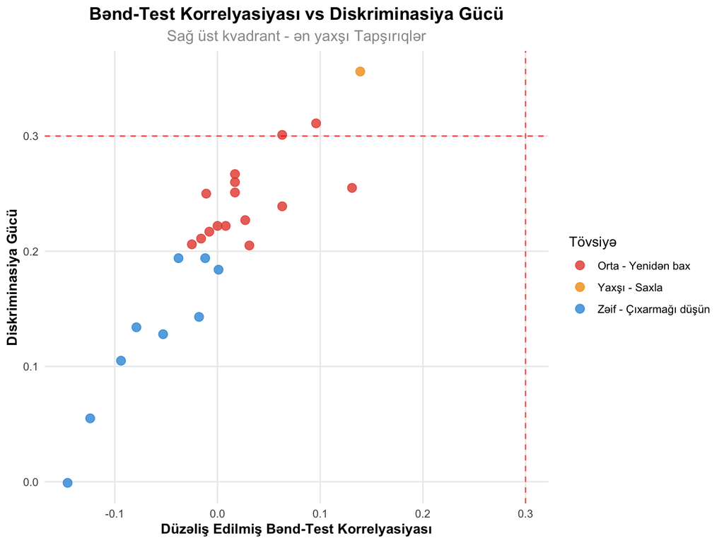

```r
# Vizuallaşdırma
item_data <- sample_analysis$item_analysis

# Bənd-test korrelyasiyası və diskriminasiya əlaqəsi
ggplot(item_data, aes(x = Düzəliş_r, y = Diskriminasiya, color = Tövsiyə)) +
  geom_point(size = 3, alpha = 0.8) +
  geom_hline(yintercept = 0.30, linetype = "dashed", color = "red", alpha = 0.7) +
  geom_vline(xintercept = 0.30, linetype = "dashed", color = "red", alpha = 0.7) +
  scale_color_manual(values = c("Əla - Mütləq saxla" = colors_basic[4],
                               "Yaxşı - Saxla" = colors_basic[3],
                               "Orta - Yenidən bax" = colors_basic[2],
                               "Zəif - Çıxarmağı düşün" = colors_basic[1])) +
  labs(title = "Bənd-Test Korrelyasiyası vs Diskriminasiya Gücü",
       subtitle = "Sağ üst kvadrant - ən yaxşı Tapşırıqlər",
       x = "Düzəliş Edilmiş Bənd-Test Korrelyasiyası",
       y = "Diskriminasiya Gücü",
       color = "Tövsiyə") +
  theme_clean()
```

# 5 **Bənd Seçimi və Test Təkmilləşdirilməsi - Tapşırıq**

## 5.1 **Tapşırığın Məqsədi**

Bu tapşırıqda bir testin Tapşırıq analizini aparacaq, zəif Tapşırıqləri müəyyən edəcək və testin keyfiyyətini təkmilləşdirəcəksiniz.

## 5.2 **Tapşırıq Ssenarisi**

```r
# Tapşırıq üçün məlumat yaradılması

set.seed(12345)
n_students <- 250
n_items <- 30

# Müxtəlif keyfiyyətdə Tapşırıqlər
item_quality_types <- c(rep("Əla", 8), rep("Yaxşı", 10), rep("Orta", 7), rep("Zəif", 5))
true_abilities <- rnorm(n_students, 0, 1)

# Test məlumatları yaradılması
assignment_test_data <- matrix(0, nrow = n_students, ncol = n_items)

for(i in 1:n_items) {
  if(item_quality_types[i] == "Əla") {
    discrimination <- runif(1, 1.5, 2.0)
    difficulty <- runif(1, -0.5, 0.5)
  } else if(item_quality_types[i] == "Yaxşı") {
    discrimination <- runif(1, 1.0, 1.5)
    difficulty <- runif(1, -1.0, 1.0)
  } else if(item_quality_types[i] == "Orta") {
    discrimination <- runif(1, 0.5, 1.0)
    difficulty <- runif(1, -1.5, 1.5)
  } else {  # Zəif
    discrimination <- runif(1, 0.1, 0.5)
    difficulty <- runif(1, -2.0, 2.0)
  }

  # IRT 2PL modeli ilə cavab ehtimalı
  prob <- pnorm(discrimination * (true_abilities - difficulty))
  assignment_test_data[, i] <- rbinom(n_students, 1, prob)
}

colnames(assignment_test_data) <- paste0("Sual_", 1:n_items)

# Tapşırıq məlumatını CSV-yə yadda saxlama
assignment_df <- as.data.frame(assignment_test_data)
assignment_df$Tələbə_ID <- 1:n_students

# İlk sütuna köçür
assignment_df <- assignment_df[, c("Tələbə_ID", paste0("Sual_", 1:n_items))]

# Əvvəlcədən analiz
initial_analysis <- item_total_analysis(assignment_test_data, "Tapşırıq Testi")

cat("=== TAPŞIRIQ MƏLUMATİNİN NÜMUNƏSI ===\n")
```

```
## === TAPŞIRIQ MƏLUMATİNİN NÜMUNƏSI ===
```

```r
print(kable(head(assignment_df[, 1:11], 8), caption = "Tapşırıq Test Məlumatı (İlk 10 sual)"))
```

```
##
##
## Table: Tapşırıq Test Məlumatı (İlk 10 sual)
##
## | Tələbə_ID| Sual_1| Sual_2| Sual_3| Sual_4| Sual_5| Sual_6| Sual_7| Sual_8| Sual_9| Sual_10|
## |---------:|------:|------:|------:|------:|------:|------:|------:|------:|------:|-------:|
## |         1|      0|      1|      1|      1|      1|      1|      1|      1|      0|       0|
## |         2|      0|      1|      1|      1|      0|      1|      1|      0|      0|       1|
## |         3|      0|      1|      0|      1|      0|      1|      0|      1|      0|       0|
## |         4|      0|      0|      1|      0|      0|      0|      1|      1|      0|       0|
## |         5|      1|      0|      1|      1|      1|      0|      1|      1|      0|       1|
## |         6|      0|      0|      0|      0|      0|      0|      0|      0|      0|       0|
## |         7|      1|      1|      1|      0|      0|      1|      1|      1|      1|       1|
## |         8|      0|      0|      0|      1|      0|      0|      0|      0|      0|       0|
```

```r
cat("\n=== İLKİN ANALİZ NƏTİCƏLƏRİ ===\n")
```

```
##
## === İLKİN ANALİZ NƏTİCƏLƏRİ ===
```

```r
print(kable(initial_analysis$summary, caption = "Test Başlanğıc Statistikaları"))
```

```
##
##
## Table: Test Başlanğıc Statistikaları
##
## |Metrik                 |  Dəyər|
## |:----------------------|------:|
## |Test uzunluğu          | 30.000|
## |Cronbach Alpha         |  0.933|
## |Orta çətinlik          |  0.551|
## |Orta bənd-test r       |  0.542|
## |Orta diskriminasiya    |  0.684|
## |Əla Tapşırıq sayı      | 25.000|
## |Zəif Tapşırıq sayı     |  0.000|
## |Tövsiyə edilən uzunluq | 30.000|
```

```r
# Tapşırıq keyfiyyət paylanması
quality_distribution <- table(initial_analysis$item_analysis$Tövsiyə)
print(kable(as.data.frame(quality_distribution), caption = "Tapşırıq Keyfiyyət Paylanması"))
```

```
##
##
## Table: Tapşırıq Keyfiyyət Paylanması
##
## |Var1               | Freq|
## |:------------------|----:|
## |Əla - Mütləq saxla |   25|
## |Yaxşı - Saxla      |    5|
```

```r
cat("\n=== TAPŞIRIQ ADDAMLARI ===\n")
```

```
##
## === TAPŞIRIQ ADDAMLARI ===
```

```r
cat("1. Məlumatı yükləyin və ilkin analiz aparın\n")
```

```
## 1. Məlumatı yükləyin və ilkin analiz aparın
```

```r
cat("2. Hər Tapşırıq üçün bənd-test korrelyasiyasını hesablayın\n")
```

```
## 2. Hər Tapşırıq üçün bənd-test korrelyasiyasını hesablayın
```

```r
cat("3. Zəif Tapşırıqləri müəyyən edin (r < 0.20)\n")
```

```
## 3. Zəif Tapşırıqləri müəyyən edin (r < 0.20)
```

```r
cat("4. Diskriminasiya gücünü qiymətləndirin\n")
```

```
## 4. Diskriminasiya gücünü qiymətləndirin
```

```r
cat("5. Çətinlik səviyyəsini analiz edin\n")
```

```
## 5. Çətinlik səviyyəsini analiz edin
```

```r
cat("6. Zəif Tapşırıqləri çıxarın\n")
```

```
## 6. Zəif Tapşırıqləri çıxarın
```

```r
cat("7. Yeni testin etibarlılığını hesablayın\n")
```

```
## 7. Yeni testin etibarlılığını hesablayın
```

```r
cat("8. Nəticələri müqayisə edin və hesabat yazın\n")
```

```
## 8. Nəticələri müqayisə edin və hesabat yazın
```

```r
# CSV faylı yadda saxla
write.csv(assignment_df, "item_analysis_assignment.csv", row.names = FALSE)
cat("\nMəlumat 'item_analysis_assignment.csv' faylına yadda saxlanıldı.\n")
```

```
##
## Məlumat 'item_analysis_assignment.csv' faylına yadda saxlanıldı.
```

## 5.3 **Bənd Seçimi Strategiyası**

```r
# Bənd seçimi strategiyasının nümayişi

# Müxtəlif strategiyaların müqayisəsi
strategy_comparison <- data.frame(
  Strategiya = c("Konservativ", "Standart", "Liberal", "Ətraflı"),

  Bənd_Test_r_Hədd = c("≥ 0.40", "≥ 0.30", "≥ 0.20", "≥ 0.25"),
  Diskriminasiya_Hədd = c("≥ 0.40", "≥ 0.30", "≥ 0.20", "≥ 0.25"),
  Çətinlik_Aralığı = c("0.40-0.70", "0.30-0.80", "0.20-0.90", "0.25-0.85"),

  Üstünlük = c("Yüksək keyfiyyət", "Balanslaşdırılmış", "Çox Tapşırıq saxlanır", "Məqsədyönlü"),
  Çatışmazlıq = c("Az Tapşırıq qalır", "Orta keyfiyyət", "Bəzi zəif Tapşırıqlər", "Mürəkkəb"),

  Tövsiyə_Sahəsi = c("Yüksək riskli testlər", "Ümumi məqsədlər", "Araşdırma", "Xüsusi məqsədlər")
)

kable(strategy_comparison, caption = "Bənd Seçimi Strategiyalarının Müqayisəsi")
```

Bənd Seçimi Strategiyalarının Müqayisəsi

| Strategiya | Bənd_Test_r_Hədd | Diskriminasiya_Hədd | Çətinlik_Aralığı | Üstünlük | Çatışmazlıq | Tövsiyə_Sahəsi |
| --- | --- | --- | --- | --- | --- | --- |
| Konservativ | ≥ 0.40 | ≥ 0.40 | 0.40-0.70 | Yüksək keyfiyyət | Az Tapşırıq qalır | Yüksək riskli testlər |
| Standart | ≥ 0.30 | ≥ 0.30 | 0.30-0.80 | Balanslaşdırılmış | Orta keyfiyyət | Ümumi məqsədlər |
| Liberal | ≥ 0.20 | ≥ 0.20 | 0.20-0.90 | Çox Tapşırıq saxlanır | Bəzi zəif Tapşırıqlər | Araşdırma |
| Ətraflı | ≥ 0.25 | ≥ 0.25 | 0.25-0.85 | Məqsədyönlü | Mürəkkəb | Xüsusi məqsədlər |

```r
# Strategiyaların tətbiqi
current_analysis <- initial_analysis$item_analysis

strategy_results <- data.frame(
  Strategiya = c("Konservativ", "Standart", "Liberal", "Ətraflı"),
  Saxlanılan_Tapşırıq = numeric(4),
  Çıxarılan_Tapşırıq = numeric(4),
  Proqnoz_Alpha = numeric(4),
  Alpha_Dəyişiklik = numeric(4)
)

strategies <- list(
  Konservativ = list(r_threshold = 0.40, disc_threshold = 0.40, diff_min = 0.40, diff_max = 0.70),
  Standart = list(r_threshold = 0.30, disc_threshold = 0.30, diff_min = 0.30, diff_max = 0.80),
  Liberal = list(r_threshold = 0.20, disc_threshold = 0.20, diff_min = 0.20, diff_max = 0.90),
  Ətraflı = list(r_threshold = 0.25, disc_threshold = 0.25, diff_min = 0.25, diff_max = 0.85)
)

for(i in 1:4) {
  strategy <- strategies[[i]]
  strategy_name <- names(strategies)[i]

  # Tapşırıq seçimi kriteriləri
  selected <- (current_analysis$Düzəliş_r >= strategy$r_threshold) &
              (current_analysis$Diskriminasiya >= strategy$disc_threshold) &
              (current_analysis$Çətinlik >= strategy$diff_min) &
              (current_analysis$Çətinlik <= strategy$diff_max)

  n_selected <- sum(selected)
  n_removed <- n_items - n_selected

  strategy_results$Saxlanılan_Tapşırıq[i] <- n_selected
  strategy_results$Çıxarılan_Tapşırıq[i] <- n_removed

  # Proqnozlaşdırılan alpha (əgər Tapşırıqlər çıxarılsa)
  if(n_selected >= 10) {  # Minimum Tapşırıq sayı
    selected_data <- assignment_test_data[, selected]
    predicted_alpha <- psych::alpha(selected_data)$total$raw_alpha
    strategy_results$Proqnoz_Alpha[i] <- predicted_alpha
    strategy_results$Alpha_Dəyişiklik[i] <- predicted_alpha - initial_analysis$original_alpha
  } else {
    strategy_results$Proqnoz_Alpha[i] <- NA
    strategy_results$Alpha_Dəyişiklik[i] <- NA
  }
}

strategy_results[, 3:5] <- round(strategy_results[, 3:5], 3)

print(kable(strategy_results, caption = "Bənd Seçimi Strategiyalarının Nəticələri"))
```

```
##
##
## Table: Bənd Seçimi Strategiyalarının Nəticələri
##
## |Strategiya  | Saxlanılan_Tapşırıq| Çıxarılan_Tapşırıq| Proqnoz_Alpha| Alpha_Dəyişiklik|
## |:-----------|-------------------:|------------------:|-------------:|----------------:|
## |Konservativ |                  18|                 12|         0.928|           -0.004|
## |Standart    |                  25|                  5|         0.941|            0.008|
## |Liberal     |                  30|                  0|         0.933|            0.000|
## |Ətraflı     |                  27|                  3|         0.938|            0.005|
```

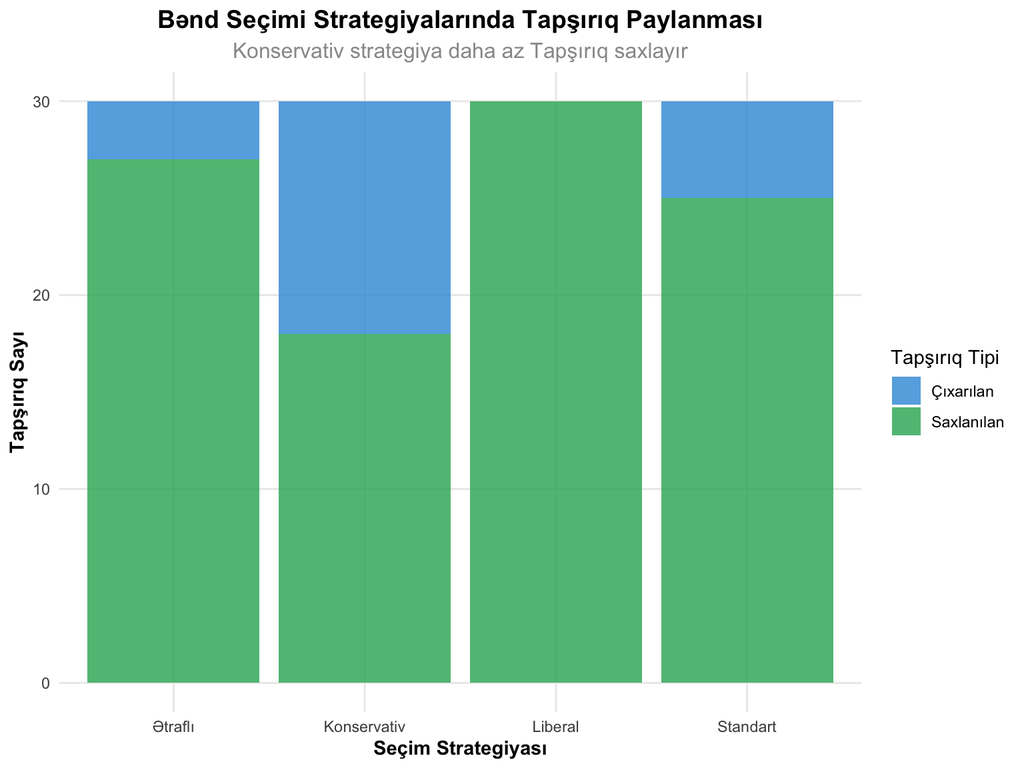

```r
# Strategiyaların vizual müqayisəsi
strategy_long <- tidyr::pivot_longer(strategy_results[, 1:3], cols = c(Saxlanılan_Tapşırıq, Çıxarılan_Tapşırıq),
                                   names_to = "Tapşırıq_Tipi", values_to = "Say")

ggplot(strategy_long, aes(x = Strategiya, y = Say, fill = Tapşırıq_Tipi)) +
  geom_col(position = "stack", alpha = 0.8) +
  scale_fill_manual(values = c("Saxlanılan_Tapşırıq" = colors_basic[4],
                              "Çıxarılan_Tapşırıq" = colors_basic[1]),
                    labels = c("Çıxarılan", "Saxlanılan")) +
  labs(title = "Bənd Seçimi Strategiyalarında Tapşırıq Paylanması",
       subtitle = "Konservativ strategiya daha az Tapşırıq saxlayır",
       x = "Seçim Strategiyası", y = "Tapşırıq Sayı", fill = "Tapşırıq Tipi") +
  theme_clean()
```

# 6 **Dərsin Xülasəsi**

## 6.1 **Əsas Nəticələr**

**Bənd-Test Korrelyasiyasının Mahiyyəti:** - ✓ **Diskriminasiya ölçməsi** - Tapşırıqnin qabiliyyət fərqlərini ayıra bilməsi - ✓ **r<sub>i(t-i)</sub>** - düzəliş edilmiş korrelyasiya daha dəqiq ölçü - ✓ **Minimum hədd: 0.30** - qəbul edilə bilər səviyyə - ✓ **Keyfiyyət göstəricisi** - Tapşırıqnin test məqsədinə uyğunluğu

**Düzəliş Formulları:** - ✓ **Part-whole problemi** - Tapşırıqnin öz testində payı - ✓ **Düzəliş edilmiş formula** - daha konservativ nəticələr - ✓ **Spearman-Brown** - test uzunluğu effekti - ✓ **Praktik seçim** - düzəliş edilmiş korrelyasiya ən faydalı

**Bənd Seçimi Kriteriləri:** - ✓ **Çoxlu kriteriya** - korrelyasiya, diskriminasiya, çətinlik - ✓ **Keyfiyyət qiyməti** - ümumi performans göstəricisi - ✓ **Strategiya seçimi** - məqsədə uyğun yanaşma - ✓ **Test təkmilləşdirilməsi** - etibarlılığın artırılması

**Praktik Tətbiq:** - ✓ **R ilə analiz** - avtomatlaşdırılmış hesablamalar - ✓ **Vizual qiymətləndirmə** - nəticələrin təsviri - ✓ **Qərar dəstəyi** - sistemli Tapşırıq seçimi - ✓ **Test optimizasiyası** - keyfiyyət/uzunluq balansı

# 7 **Ev Tapşırığı**

## 7.1 **Tapşırıq 1: Tapşırıq Analizi (45 xal)**

```r
# Tapşırıq analizi tapşırığı

# TAPŞİRIQ HƏLLI:
# 1. item_analysis_assignment.csv faylını yükləyin
# 2. Hərtərəfli Tapşırıq analizi aparın
# 3. Zəif Tapşırıqləri müəyyən edin
# 4. Test təkmilləşdirilməsi strategiyası təklif edin
# 5. Nəticələri interpretasiya edin

# Başlanğıc kod:
data <- read.csv("item_analysis_assignment.csv")
test_data <- data[, -1]  # Tələbə ID-ni çıxar

# Kodunuzu buraya yazın...
print("Tapşırıq ANALİZİ NƏTİCƏLƏRİ:")
print("Zəif Tapşırıqlər:")
print("Tövsiyə edilən dəyişikliklər:")
print("Gözlənilən təkmilləşmə:")
```

## 7.2 **Tapşırıq 2: Test Təkmilləşdirilməsi (35 xal)**

**Praktik test təkmilləşdirilməsi aparın:**

1. **Zəif Tapşırıqləri çıxarın** və yeni test yaradın
2. **Etibarlılıq dəyişikliyini** hesablayın
3. **Tapşırıq statistikalarını** müqayisə edin
4. **Vizuallaşdırma** yaradın (scatter plot, histogram)
5. **Tövsiyələr** yazın (400 söz)

## 7.3 **Tapşırıq 3: Strategiya Müqayisəsi (20 xal)**

**Müxtəlif bənd seçimi strategiyalarını müqayisə edin:**

1. **4 strategiya** tətbiq edin
2. **Nəticələri cədvəldə** göstərin
3. **Hansı strategiya ən yaxşıdır?** - əsaslandırın
4. **Praktik tövsiyələr** - konkret vəziyyətlər üçün

# 8 **Növbəti Dərslərə Hazırlıq**

## 8.1 **Dərs 14: “Validlik Anlayışı”**

Növbəti dərsdə öyrənəcəklər:

- ✓ Validliyin təyini və etibarlılıqla əlaqəsi
- ✓ Məzmun validliyi və ekspert qiymətləndirməsi
- ✓ Kriteriya validliyi və proqnozlaşdırma
- ✓ Konstrukt validliyi və faktor analizi

## 8.2 **Dərs 15: “Faktorial Validlik”**

Sonrakı mövzular:

- ✓ Eksplorator və konfirmator faktor analizi
- ✓ Faktorial strukturun qiymətləndirilməsi
- ✓ Model uyğunluq göstəriciləri
- ✓ Çoxölçülü testlərin validlik analizi

# 9 **Tapşırıq Analizinin Gələcəyi**

## 9.1 **Müasir İnkişaflar**

**Texnoloji Yeniliklər:** - **Machine Learning** - avtomatik Tapşırıq seçimi - **Big Data Analytics** - böyük məlumat analizi - **Real-time Analysis** - canlı Tapşırıq performansı - **Adaptive Testing** - dinamik Tapşırıq seçimi

**Metodoloji Təkmilləşdirmələr:** - **IRT əsaslı Tapşırıq analizi** - daha dəqiq parametrlər - **Bayesian Item Analysis** - önceki məlumatın istifadəsi - **Multi-group Analysis** - qrup fərqlərinin nəzarəti - **Computerized Adaptive Testing** - fərdi uyğunlaşma

## 9.2 **Praktik Tövsiyələr Xülasəsi**

```r
# Tapşırıq analizinin praktik tövsiyələri

final_item_recommendations <- data.frame(
  Vəziyyət = c("Yeni test hazırlama", "Mövcud test təkmilləşdirilməsi", "Böyük məlumat analizi",
               "Klinik qiymətləndirmə", "Təhsil sektoru", "Araşdırma məqsədləri"),

  Tövsiyə_Metodu = c("Ətraflı analiz", "Standart analiz", "Avtomatlaşdırılmış",
                     "Konservativ analiz", "Balanslaşdırılmış", "Liberal analiz"),

  Prioritet_Kriteriya = c("Keyfiyyət", "Təkmilləşdirmə", "Səmərəlilik",
                          "Dəqiqlik", "Praktiklik", "Kəşfiyyat"),

  r_Hədd = c("≥ 0.35", "≥ 0.30", "≥ 0.25", "≥ 0.40", "≥ 0.30", "≥ 0.20"),

  Diskriminasiya_Hədd = c("≥ 0.35", "≥ 0.30", "≥ 0.25", "≥ 0.40", "≥ 0.30", "≥ 0.20"),

  Gözlənilən_Nəticə = c("Yüksək keyfiyyət", "Təkmilləşmiş test", "Səmərəli proses",
                        "Güvənilir qiymətləndirmə", "Balanslaşdırılmış", "Kəşfiyyat")
)

kable(final_item_recommendations, caption = "Tapşırıq Analizi üçün Praktik Tövsiyələr")
```

Tapşırıq Analizi üçün Praktik Tövsiyələr

| Vəziyyət | Tövsiyə_Metodu | Prioritet_Kriteriya | r_Hədd | Diskriminasiya_Hədd | Gözlənilən_Nəticə |
| --- | --- | --- | --- | --- | --- |
| Yeni test hazırlama | Ətraflı analiz | Keyfiyyət | ≥ 0.35 | ≥ 0.35 | Yüksək keyfiyyət |
| Mövcud test təkmilləşdirilməsi | Standart analiz | Təkmilləşdirmə | ≥ 0.30 | ≥ 0.30 | Təkmilləşmiş test |
| Böyük məlumat analizi | Avtomatlaşdırılmış | Səmərəlilik | ≥ 0.25 | ≥ 0.25 | Səmərəli proses |
| Klinik qiymətləndirmə | Konservativ analiz | Dəqiqlik | ≥ 0.40 | ≥ 0.40 | Güvənilir qiymətləndirmə |
| Təhsil sektoru | Balanslaşdırılmış | Praktiklik | ≥ 0.30 | ≥ 0.30 | Balanslaşdırılmış |
| Araşdırma məqsədləri | Liberal analiz | Kəşfiyyat | ≥ 0.20 | ≥ 0.20 | Kəşfiyyat |

# 10 **Əlavə Resurslar və Ədəbiyyat**

## 10.1 **Əsas Mənbələr**

**Məcburi oxu:** - Allen, M.J., & Yen, W.M. (2002). *Introduction to Measurement Theory*. Fəsil 7: “Item Analysis” - Crocker, L., & Algina, J. (1986). *Introduction to Classical and Modern Test Theory*. Fəsil 10

**Əlavə ədəbiyyat:** - Ebel, R.L., & Frisbie, D.A. (1991). *Essentials of Educational Measurement*. Fəsil 11 - Thorndike, R.M. (2005). *Measurement and Evaluation in Psychology and Education*. Fəsil 9

## 10.2 **R Paketləri və Funksiyalar**

**Tapşırıq Analizi:**

```r
# Əsas analizlər
psych::alpha()                     # Cronbach alpha və item statistics
psych::item.exam()                 # Hərtərəfli Tapşırıq analizi
cor()                              # Sadə korrelyasiyalar

# Təkmilləşdirilmiş analizlər
ltm::descript()                    # Deskriptiv item analizi
CTT::itemAnalysis()                # Klassik test nəzəriyyəsi
psychometrics::item.exam()         # Tapşırıq təfsilatları
```

## 10.3 **Təbriklər!**

Bənd-test korrelyasiyasının bütün aspektlərini əhatə etdiniz! İndi Tapşırıq analizini necə aparmaq və testləri necə təkmilləşdirmək lazım olduğunu bilirsiniz.

**Növbəti dərsdə validlik anlayışının sirləri ilə tanış olacaqsınız! 🎯**

*Bu dərs Allen və Yen (2002) “Introduction to Measurement Theory” kitabının 7-ci fəslinə əsaslanır.*

**Son yenilənmə:** 2025-07-18 | **Versiya:** 1.0